# Session 3 Get Learning

Steph de Silva

28/10/2018

## knn - k nearest neighbours

Clustering is an *unsupevised* machine learning technique. We can use it when we want to look at groups, but we have no means of labelling them.

Let’s start with some data, but first some packages.

```r
library(tidyverse)
library(readxl)
```

Now let’s get the data. In this case, let’s look at the loanbook of Ratesetter, an Australian fintech. We’re using the package `readxl`, which does exactly what it says on the box.

```r
loan_book <- read_xlsx("./data/20170630loanbook-1.xlsx", sheet = "RSLoanBook", col_names = TRUE, skip = 8)
```

What we’d like to do is examine the different types of loans and see if there are any ‘natural’ clusters. First, we need a serious data analysis on our data though.

```r
head(loan_book)
```

```
## # A tibble: 6 x 15
##   ContractID        ContractDate        LoanTerm AnnualRate FinanceAmount
##   <chr>             <dttm>                 <dbl>      <dbl>         <dbl>
## 1 E7D81DD7-55334113 2014-10-30 00:00:00      24.     0.0747        30470.
## 2 97DAED44-89634919 2014-10-31 00:00:00      60.     0.101          2489.
## 3 FFB78354-19953790 2014-11-11 00:00:00      36.     0.0830        15631.
## 4 3F4FFC33-94020362 2014-11-14 00:00:00       9.     0.0649        10430.
## 5 FE1CE069-19746554 2014-11-18 00:00:00      60.     0.101         18473.
## 6 89F79EDB-44008873 2014-11-19 00:00:00      60.     0.107         32175.
## # ... with 10 more variables: PrincipalOutstanding <dbl>,
## #   FinancePurpose <chr>, BorrowerState <chr>, BorrowerAge <chr>,
## #   EmploymentStatus <chr>, BorrowerIncome <chr>, HousingStatus <chr>,
## #   Gender <chr>, EarlyPaymentsMade <chr>, RepaymentStatus <chr>
```

OK so we have 15 variables and over 9500 observations. Remember `skimr`? Let’s use that.

```r
library(skimr)
skim(loan_book)
```

```
## Skim summary statistics
##  n obs: 9526
##  n variables: 15
##
## ── Variable type:character ───────────────────────────────────────────────────────────────────────────────
##           variable missing complete    n min max empty n_unique
##        BorrowerAge       0     9526 9526   3   5     0        8
##     BorrowerIncome       0     9526 9526   5   9     0        4
##      BorrowerState       0     9526 9526   2   3     0        8
##         ContractID       0     9526 9526  17  17     0     9526
##  EarlyPaymentsMade       0     9526 9526   2   3     0        2
##   EmploymentStatus       0     9526 9526   8  18     0        6
##     FinancePurpose       0     9526 9526   8  21     0       10
##             Gender       0     9526 9526   4   6     0        2
##      HousingStatus       0     9526 9526  17  24     0        4
##    RepaymentStatus       0     9526 9526   6  13     0        6
##
## ── Variable type:numeric ─────────────────────────────────────────────────────────────────────────────────
##              variable missing complete    n      mean        sd      p0
##            AnnualRate       0     9526 9526     0.071     0.026   0.029
##         FinanceAmount       0     9526 9526 14076.71  10562.4   139
##              LoanTerm       0     9526 9526    33.15     17.78    6
##  PrincipalOutstanding       0     9526 9526  9111.65   9528.62    0
##       p25       p50       p75      p100     hist
##     0.045     0.082     0.096      0.12 ▂▇▁▁▂▆▅▁
##  5430.73  10885.81  20542.3   152523.9  ▇▃▁▁▁▁▁▁
##    18        36        48         84    ▇▇▁▇▂▇▁▁
##   690.07   6113.15  14148.45  152523.9  ▇▁▁▁▁▁▁▁
##
## ── Variable type:POSIXct ─────────────────────────────────────────────────────────────────────────────────
##      variable missing complete    n        min        max     median
##  ContractDate       0     9526 9526 2014-10-30 2017-06-30 2016-12-05
##  n_unique
##       790
```

There are a number of character variables that would be better as factors, so we can use them more effectively. Let’s swap them over.

One way to do this is use the `as.factor()` function.

Some of these like age and income are actually ordered, so we will tell R what the order should be. To do that, we use the `factor()` function and the `levels` argument.

```r
loan_book$BorrowerAge <- factor(loan_book$BorrowerAge, levels = c("<20", "20-29", "30-39" , "40-49", "50-59", "60-69", "70-79", "80-89"))
str(loan_book$BorrowerAge)
```

```
##  Factor w/ 8 levels "<20","20-29",..: 6 2 4 3 4 3 5 4 4 4 ...
```

Let’s go ahead and do the rest.

```r
loan_book$FinancePurpose <- as.factor(loan_book$FinancePurpose)
loan_book$EmploymentStatus <- as.factor(loan_book$EmploymentStatus)
loan_book$BorrowerIncome <- factor(loan_book$BorrowerIncome, levels = c("<$50K", "$50-100K", "$100-150K", ">$150K"))
loan_book$HousingStatus <- as.factor(loan_book$HousingStatus)
loan_book$Gender <- as.factor(loan_book$Gender)
loan_book$EarlyPaymentsMade <- as.factor(loan_book$EarlyPaymentsMade)
loan_book$RepaymentStatus <- as.factor(loan_book$RepaymentStatus)
```

In any good data analysis, there’s alot of viz to tell us what’s going on. Let’s take a look. Here’s one of the loan terms, with both mean (purple) and median (blue) marked.

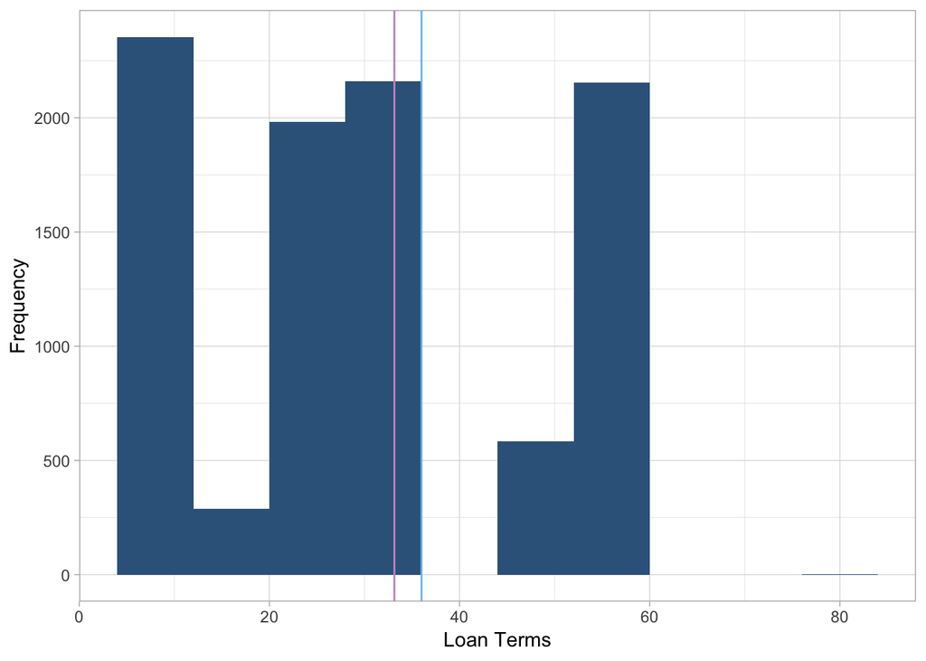

```r
ggplot(loan_book)+
  geom_histogram(aes(LoanTerm), binwidth = 8,
                 fill = "steelblue4", na.rm = TRUE)+
  geom_vline(aes(xintercept = mean(LoanTerm, na.rm = TRUE)),
             colour = "plum3")+
  geom_vline(aes(xintercept = median(LoanTerm, na.rm = TRUE)),
             colour = "skyblue2") +
  theme_light() +
  xlab("Loan Terms")+
  ylab("Frequency")
```

The rate of the loans:

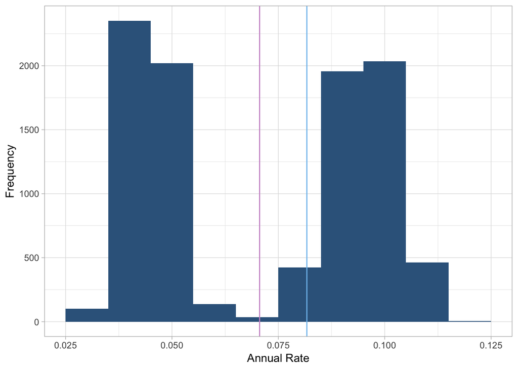

```r
ggplot(loan_book)+
  geom_histogram(aes(AnnualRate), binwidth = 0.01,
                 fill = "steelblue4", na.rm = TRUE)+
  geom_vline(aes(xintercept = mean(AnnualRate, na.rm = TRUE)),
             colour = "plum3")+
  geom_vline(aes(xintercept = median(AnnualRate, na.rm = TRUE)),
             colour = "skyblue2") +
  theme_light() +
  xlab("Annual Rate")+
  ylab("Frequency")
```

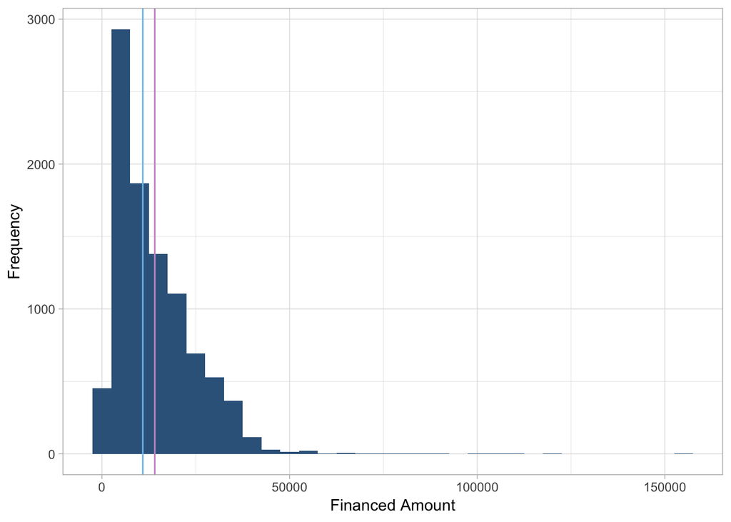

```r
ggplot(loan_book)+
  geom_histogram(aes(FinanceAmount), binwidth = 5000,
                 fill = "steelblue4", na.rm = TRUE)+
  geom_vline(aes(xintercept = mean(FinanceAmount, na.rm = TRUE)),
             colour = "plum3")+
  geom_vline(aes(xintercept = median(FinanceAmount, na.rm = TRUE)),
             colour = "skyblue2") +
  theme_light() +
  xlab("Financed Amount")+
  ylab("Frequency")
```

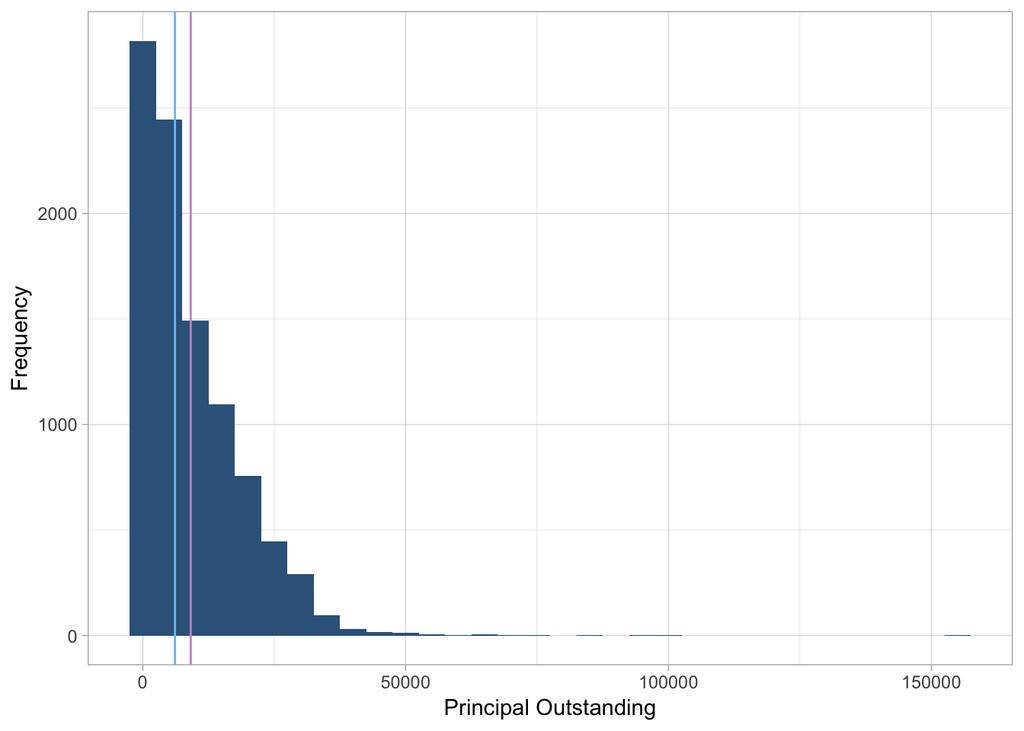

```r
ggplot(loan_book)+
  geom_histogram(aes(PrincipalOutstanding), binwidth = 5000,
                 fill = "steelblue4", na.rm = TRUE)+
  geom_vline(aes(xintercept = mean(PrincipalOutstanding, na.rm = TRUE)),
             colour = "plum3")+
  geom_vline(aes(xintercept = median(PrincipalOutstanding, na.rm = TRUE)),
             colour = "skyblue2") +
  theme_light() +
  xlab("Principal Outstanding")+
  ylab("Frequency")
```

Let’s turn our attention to the location of the borrower. As we’d expect, the more populous states on the eastern seaboard dominate the borrowers. It doesn’t make alot of sense to try and average “states”, so we’ll leave that for now!

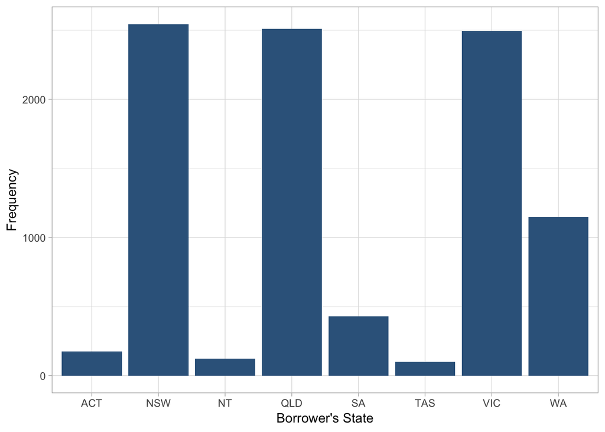

```r
ggplot(loan_book)+
  geom_bar(aes(BorrowerState),
                 fill = "steelblue4")+
  theme_light() +
  xlab("Borrower's State")+
  ylab("Frequency")
```

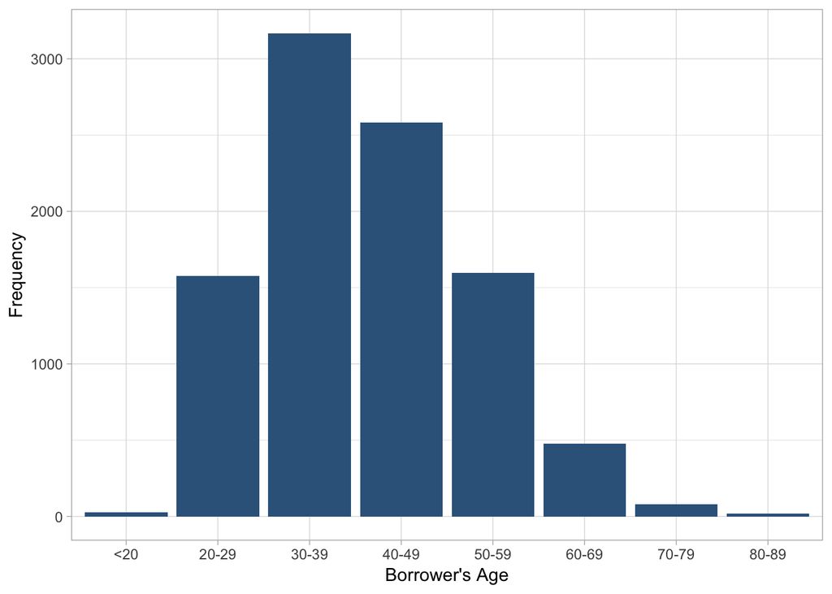

```r
ggplot(loan_book)+
  geom_bar(aes(BorrowerAge),
                 fill = "steelblue4")+
  theme_light() +
  xlab("Borrower's Age")+
  ylab("Frequency")
```

This is another interesting distribution, slightly positively skewed, it appears the modal borrower is between 30-39, with very few borrowers under 20 or over 80.

The next chart shows that the modal borrower is employed full time, while some are self employed or employed part time. Very few people with the status *houseperson* have accessed Ratesetter for loans. Why do you think that may be? Why so few retirees? Is there another variable that might be related to this?

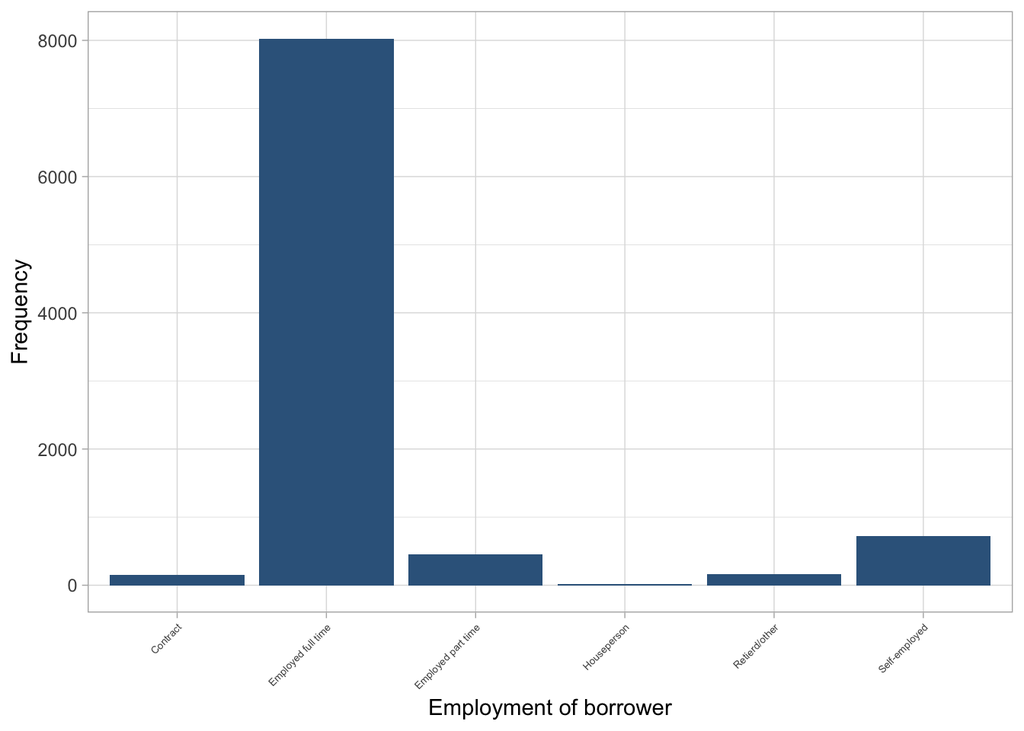

```r
ggplot(loan_book)+
  geom_bar(aes(EmploymentStatus),
                 fill = "steelblue4")+
  theme_light() +
  theme(axis.text.x=element_text(angle=45,hjust=1,
                                 size = 5)) +
  xlab("Employment of borrower")+
  ylab("Frequency")
```

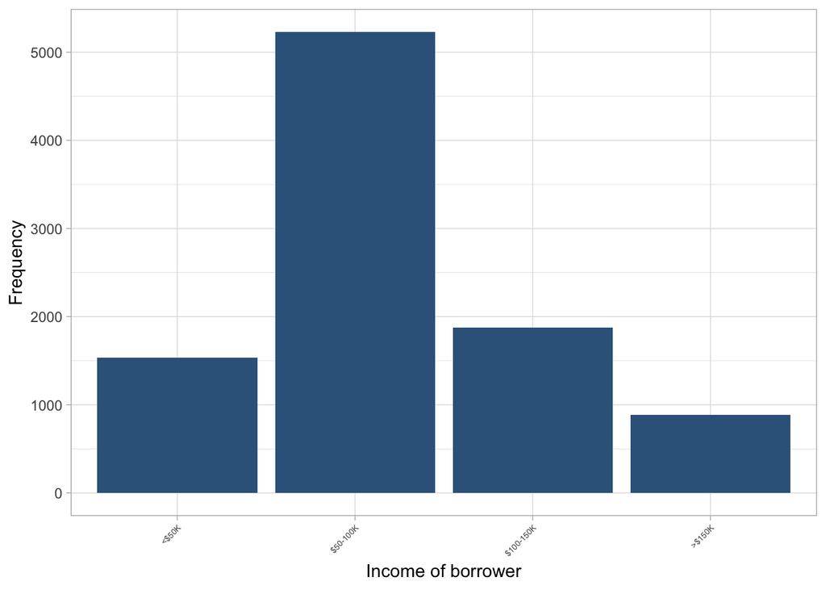

```r
ggplot(loan_book)+
  geom_bar(aes(BorrowerIncome),
                 fill = "steelblue4")+
  theme_light() +
  theme(axis.text.x=element_text(angle=45,hjust=1,
                                 size = 5)) +
  xlab("Income of borrower")+
  ylab("Frequency")
```

Another slightly positively skewed distribution, with the majority of borrowers in the $50-100k income range.

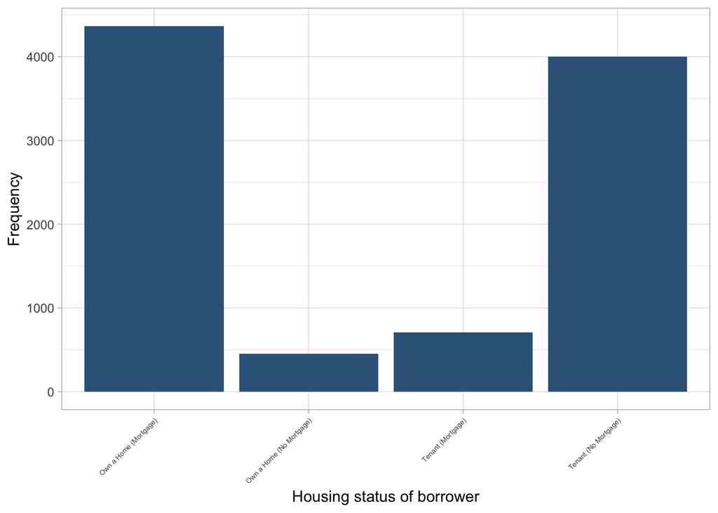

```r
ggplot(loan_book)+
  geom_bar(aes(HousingStatus),
                 fill = "steelblue4")+
  theme_light() +
  theme(axis.text.x=element_text(angle=45,hjust=1,
                                 size = 5)) +
  xlab("Housing status of borrower")+
  ylab("Frequency")
```

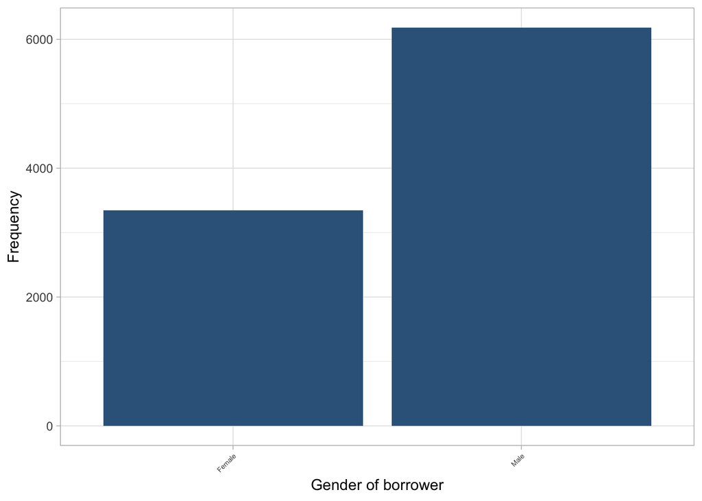

```r
ggplot(loan_book)+
  geom_bar(aes(Gender),
                 fill = "steelblue4")+
  theme_light() +
  theme(axis.text.x=element_text(angle=45,hjust=1,
                                 size = 5)) +
  xlab("Gender of borrower")+
  ylab("Frequency")
```

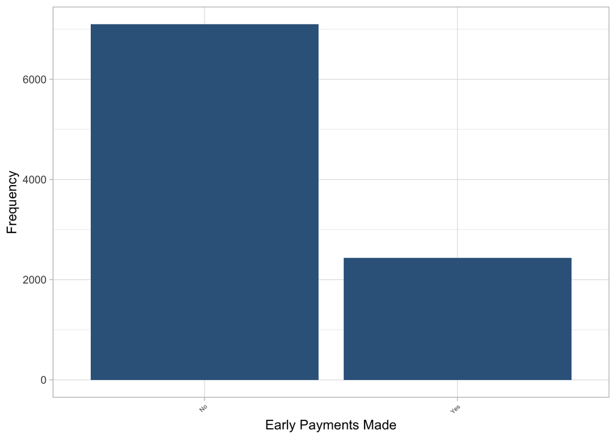

```r
ggplot(loan_book)+
  geom_bar(aes(EarlyPaymentsMade),
                 fill = "steelblue4")+
  theme_light() +
  theme(axis.text.x=element_text(angle=45,hjust=1,
                                 size = 5)) +
  xlab("Early Payments Made")+
  ylab("Frequency")
```

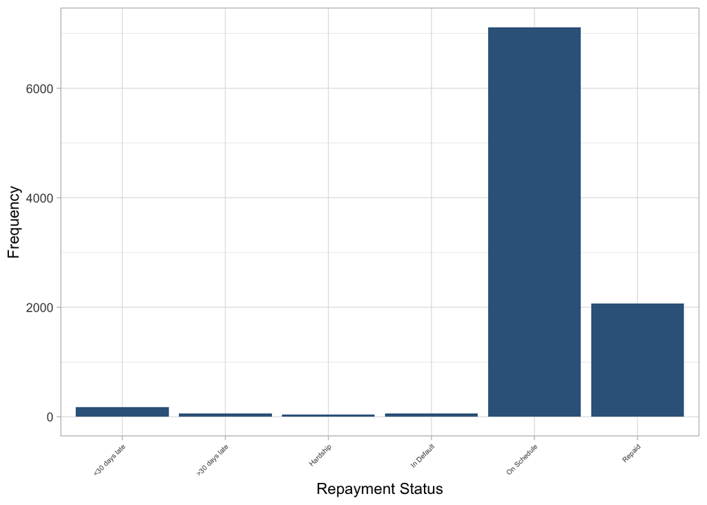

```r
ggplot(loan_book)+
  geom_bar(aes(RepaymentStatus),
                 fill = "steelblue4")+
  theme_light() +
  theme(axis.text.x=element_text(angle=45,hjust=1,
                                 size = 5)) +
  xlab("Repayment Status")+
  ylab("Frequency")
```

Let’s start with a simple line chart for the contract date (the date the loan was signed off) and the rate of interest paid by the borrower.

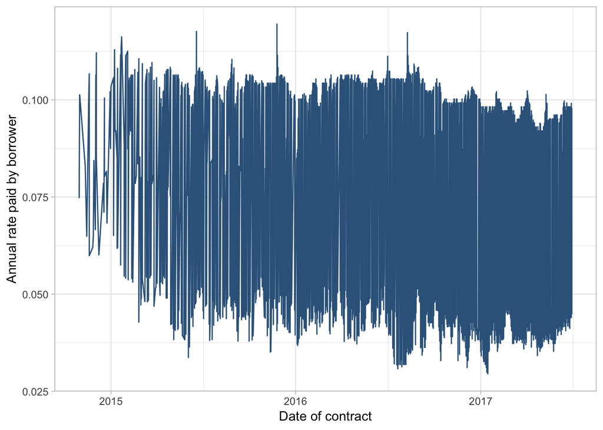

```r
ggplot(loan_book) +
  geom_line(aes(ContractDate, AnnualRate),
            colour = "steelblue4") +
  theme_light()+
  xlab("Date of contract") +
  ylab("Annual rate paid by borrower")
```

In technical terms, we like to refer to a chart like this as a ‘hot mess’. For the love of all that’s geeky, never let a chart like this off your hard drive. I’m only including this here so you know what to do if you find one of these: *you ask more questions*.

What’s going on here? Well it’s hard to say. The rate being paid each year is largely between around 3% and 10% with some variation outside that. This is where we start using what consultants call *business acumen* and normal people call *common sense*.

What’s something that could be causing a big variation in the rate paid between two loans contracted within a very short period? Interest rates are pretty stable for retail loans, right? Well, here’s where domain knowledge is useful. If you know anything about finance, you know the loan term is a good candidate to start with. Let’s see what we can dig up there.

If we want to see what the relationship between the loan term and annual rate paid is, a scatterplot is a good first step.

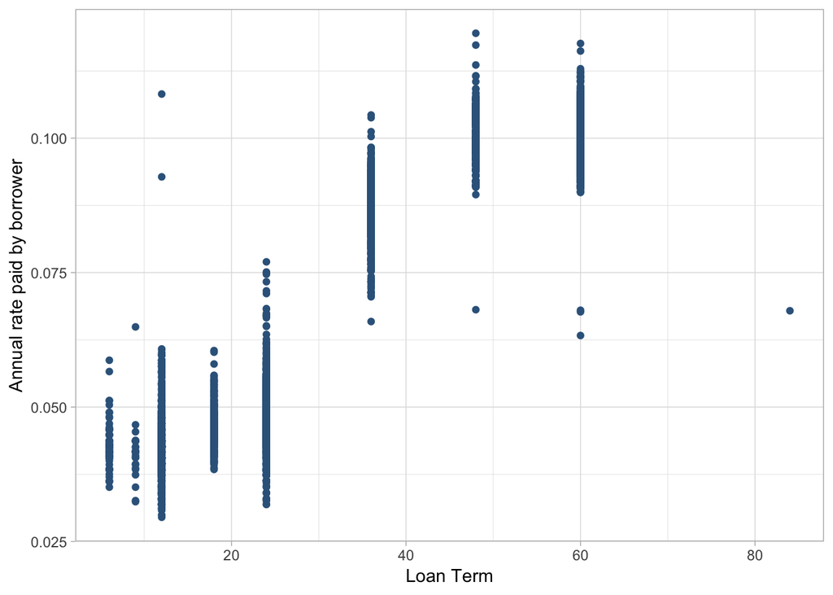

```r
ggplot(loan_book) +
  geom_point(aes(LoanTerm, AnnualRate),
            colour = "steelblue4") +
  theme_light()+
  xlab("Loan Term") +
  ylab("Annual rate paid by borrower")
```

Well, no easy answers here. While it does look like there is a relationship between annual rate and loan term, where annual rate increases with loan term - there are a few observations with very long loan terms that don’t fit the pattern at all.

Welcome to real data.

The best option is simply to keep digging here, in my opinion.

What about financed amount and the annual rate?

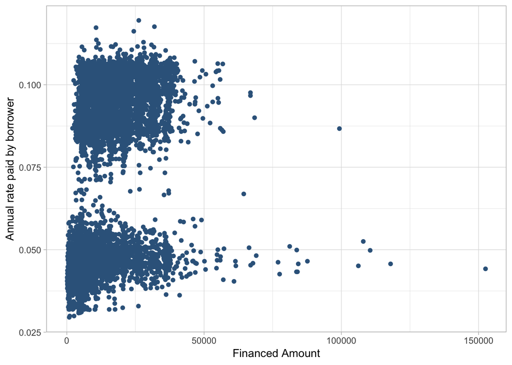

```r
ggplot(loan_book) +
  geom_point(aes(FinanceAmount, AnnualRate),
            colour = "steelblue4") +
  theme_light()+
  xlab("Financed Amount") +
  ylab("Annual rate paid by borrower")
```

Again, no easy answers! Why on earth would people borrowing the same or similar amounts be paying such remarkably different interest rates? What are the factors that could be in play here? Here’s that domain knowledge coming through again- it could be something about the person (are they ‘risky’?) or the loan (‘is the loan more risky’?).

What makes a person ‘risky’? Their income, their borrowing history (not given), their employment and even their age can be perceived as risk.

What about a loan? The financed amount, the status of the loan (is it in arrears), the term - all these things can contribute to risk too.

Let’s see if we can colour off the difference in loan term in this chart by creating a variable called shortTerm. This variable is 1 if the loan has a term of 24 months or less and zero otherwise. For convenience when plotting, we’ll turn it into a factor variable with labels and add it to the loan book.

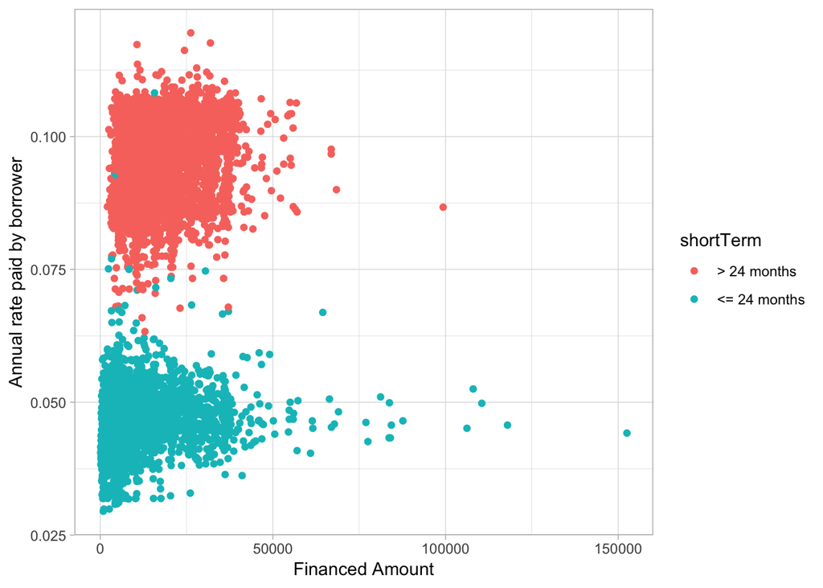

```r
shortTerm <- ifelse(loan_book$LoanTerm <= 24, 1, 0)
shortTerm <- factor(shortTerm)
levels(shortTerm) <- c("> 24 months", "<= 24 months")
loan_book <- cbind(loan_book, shortTerm)

ggplot(loan_book) +
  geom_point(aes(FinanceAmount, AnnualRate, colour = shortTerm)) +
  theme_light()+
  xlab("Financed Amount") +
  ylab("Annual rate paid by borrower")
```

And bingo! We now have a pretty good idea of what’s causing the difference in interest rates: it’s the loan term. Short term loans are less risky than long term ones and the borrower is compensated with a lower interest rate.

# Actually doing the machine learning

First we need to standardise the numeric variables. We’ll write a function to do this:

```r
standardise_variables <- function(our_variable){
  z_score <- (our_variable - mean(our_variable))/sd(our_variable)
  return(z_score)
}
```

Now we have define our function, we can apply it to our data frame, but let’s call it by a new name so we know what’s going on. We’re going to use the package `purrr`, so if you don’t have it installed, you’ll need to use `install.packages("purrr")`.

The useful thing about `purrr` is that you can apply a function to many columns of a data frame.

```r
library(purrr)
df_numeric <- loan_book[,3:6]
ml_df <- map_dfr(df_numeric, standardise_variables)

# Let's add repayment status

ml_df$RepaymentStatus <- loan_book$RepaymentStatus
```

```r
p = 0.7 # 70% of the set
n_rows <- round(nrow(ml_df)*0.7, digits = 0) # number of rows that would be
randomIndex <- runif(n_rows, min = 1, max = nrow(ml_df))

train_set <- ml_df[randomIndex,]
test_set <- ml_df[-randomIndex,]
```

Let’s use the `class` package to run `knn` algorithm. Let’s see how it goes on the repayment status label we added earlier.

```r
#install.packages("class")
library(class)
train_labels <- train_set[[5]]
test_labels <- test_set[[5]]
predictions <- knn(train = train_set[,1:4], test = test_set[,1:4], cl = train_labels, k = 3)
```

Let’s see how good we did!

```r
#install.packages("gmodels")
library(gmodels)
results_table <- CrossTable(x = test_labels, y = predictions, prop.chisq = FALSE)
```

```
##
##
##    Cell Contents
## |-------------------------|
## |                       N |
## |           N / Row Total |
## |           N / Col Total |
## |         N / Table Total |
## |-------------------------|
##
##
## Total Observations in Table:  4679
##
##
##               | predictions
##   test_labels | <30 days late | >30 days late |      Hardship |    In Default |   On Schedule |        Repaid |     Row Total |
## --------------|---------------|---------------|---------------|---------------|---------------|---------------|---------------|
## <30 days late |             0 |             0 |             0 |             0 |            80 |             1 |            81 |
##               |         0.000 |         0.000 |         0.000 |         0.000 |         0.988 |         0.012 |         0.017 |
##               |         0.000 |         0.000 |         0.000 |         0.000 |         0.023 |         0.001 |               |
##               |         0.000 |         0.000 |         0.000 |         0.000 |         0.017 |         0.000 |               |
## --------------|---------------|---------------|---------------|---------------|---------------|---------------|---------------|
## >30 days late |             1 |             1 |             0 |             0 |            34 |             0 |            36 |
##               |         0.028 |         0.028 |         0.000 |         0.000 |         0.944 |         0.000 |         0.008 |
##               |         0.024 |         0.045 |         0.000 |         0.000 |         0.010 |         0.000 |               |
##               |         0.000 |         0.000 |         0.000 |         0.000 |         0.007 |         0.000 |               |
## --------------|---------------|---------------|---------------|---------------|---------------|---------------|---------------|
##      Hardship |             1 |             0 |             0 |             0 |            19 |             0 |            20 |
##               |         0.050 |         0.000 |         0.000 |         0.000 |         0.950 |         0.000 |         0.004 |
##               |         0.024 |         0.000 |         0.000 |         0.000 |         0.005 |         0.000 |               |
##               |         0.000 |         0.000 |         0.000 |         0.000 |         0.004 |         0.000 |               |
## --------------|---------------|---------------|---------------|---------------|---------------|---------------|---------------|
##    In Default |             0 |             0 |             0 |             0 |             0 |            34 |            34 |
##               |         0.000 |         0.000 |         0.000 |         0.000 |         0.000 |         1.000 |         0.007 |
##               |         0.000 |         0.000 |         0.000 |         0.000 |         0.000 |         0.031 |               |
##               |         0.000 |         0.000 |         0.000 |         0.000 |         0.000 |         0.007 |               |
## --------------|---------------|---------------|---------------|---------------|---------------|---------------|---------------|
##   On Schedule |            39 |            21 |            12 |             4 |          3365 |            58 |          3499 |
##               |         0.011 |         0.006 |         0.003 |         0.001 |         0.962 |         0.017 |         0.748 |
##               |         0.951 |         0.955 |         1.000 |         0.364 |         0.960 |         0.053 |               |
##               |         0.008 |         0.004 |         0.003 |         0.001 |         0.719 |         0.012 |               |
## --------------|---------------|---------------|---------------|---------------|---------------|---------------|---------------|
##        Repaid |             0 |             0 |             0 |             7 |             9 |           993 |          1009 |
##               |         0.000 |         0.000 |         0.000 |         0.007 |         0.009 |         0.984 |         0.216 |
##               |         0.000 |         0.000 |         0.000 |         0.636 |         0.003 |         0.914 |               |
##               |         0.000 |         0.000 |         0.000 |         0.001 |         0.002 |         0.212 |               |
## --------------|---------------|---------------|---------------|---------------|---------------|---------------|---------------|
##  Column Total |            41 |            22 |            12 |            11 |          3507 |          1086 |          4679 |
##               |         0.009 |         0.005 |         0.003 |         0.002 |         0.750 |         0.232 |               |
## --------------|---------------|---------------|---------------|---------------|---------------|---------------|---------------|
##
##
```

```r
results_table
```

```
## $t
##                y
## x               <30 days late >30 days late Hardship In Default
##   <30 days late             0             0        0          0
##   >30 days late             1             1        0          0
##   Hardship                  1             0        0          0
##   In Default                0             0        0          0
##   On Schedule              39            21       12          4
##   Repaid                    0             0        0          7
##                y
## x               On Schedule Repaid
##   <30 days late          80      1
##   >30 days late          34      0
##   Hardship               19      0
##   In Default              0     34
##   On Schedule          3365     58
##   Repaid                  9    993
##
## $prop.row
##                y
## x               <30 days late >30 days late    Hardship  In Default
##   <30 days late   0.000000000   0.000000000 0.000000000 0.000000000
##   >30 days late   0.027777778   0.027777778 0.000000000 0.000000000
##   Hardship        0.050000000   0.000000000 0.000000000 0.000000000
##   In Default      0.000000000   0.000000000 0.000000000 0.000000000
##   On Schedule     0.011146042   0.006001715 0.003429551 0.001143184
##   Repaid          0.000000000   0.000000000 0.000000000 0.006937562
##                y
## x               On Schedule      Repaid
##   <30 days late 0.987654321 0.012345679
##   >30 days late 0.944444444 0.000000000
##   Hardship      0.950000000 0.000000000
##   In Default    0.000000000 1.000000000
##   On Schedule   0.961703344 0.016576165
##   Repaid        0.008919722 0.984142716
##
## $prop.col
##                y
## x               <30 days late >30 days late     Hardship   In Default
##   <30 days late  0.0000000000  0.0000000000 0.0000000000 0.0000000000
```

[output cut: 16 more lines]

```
## x               <30 days late >30 days late     Hardship   In Default
##   <30 days late  0.0000000000  0.0000000000 0.0000000000 0.0000000000
##   >30 days late  0.0002137209  0.0002137209 0.0000000000 0.0000000000
##   Hardship       0.0002137209  0.0000000000 0.0000000000 0.0000000000
##   In Default     0.0000000000  0.0000000000 0.0000000000 0.0000000000
##   On Schedule    0.0083351143  0.0044881385 0.0025646506 0.0008548835
##   Repaid         0.0000000000  0.0000000000 0.0000000000 0.0014960462
##                y
## x                On Schedule       Repaid
##   <30 days late 0.0170976704 0.0002137209
##   >30 days late 0.0072665099 0.0000000000
##   Hardship      0.0040606967 0.0000000000
##   In Default    0.0000000000 0.0072665099
##   On Schedule   0.7191707630 0.0123958111
##   Repaid        0.0019234879 0.2122248344
```